# Comparison of Model Performance for Classification of Olive Oils

Derick Malavi

2024-04-26

# 1 Load Libraries

```r
suppressWarnings({library(readr)
library(readxl)
library(car)
library(PMCMRplus)
library(ggplot2)
library(tidyr)
library(dplyr)
library(skimr)
library(janitor)
library(lattice)})
```

- The goal is to compare models the performance of binary classification models: PLS-DA, KNN, RF, SVM, and Neural Networks Models using the Matthews correlation coefficient (MCC) values.
- Why MCC? The MCC is particularly useful for its ability to deal with class imbalances, providing a single number that gives a comprehensive picture of the model’s effectiveness. It comprehensively includes all the observations from the confusion matrix TN, TP, FN and FP.

# 2 Import and check data

```r
model_data<-read_excel("Compiled_Model_1SE.xlsx")
model_data<-clean_names(model_data)

#Convert the pre-processing and models to factors
model_data$pre_processing<-as.factor(model_data$pre_processing)
model_data$model<-as.factor(model_data$model)
model_data$model_preprocessing<-as.factor(model_data$model_preprocessing)
head(model_data)
```

```
# A tibble: 6 × 4
  pre_processing model  model_preprocessing   mcc
  <fct>          <fct>  <fct>               <dbl>
1 Unprocessed    PLS-DA PLS-DA&Unprocessed   1
2 SG             PLS-DA PLS-DA&SG            1
3 SG_1D          PLS-DA PLS-DA&SG_1D         1
4 SG_2D          PLS-DA PLS-DA&SG_2D         0.91
5 SNV            PLS-DA PLS-DA&SNV           1
6 SNV_SG         PLS-DA PLS-DA&SNV_SG        1
```

```r
colnames(model_data)
```

```
[1] "pre_processing"      "model"               "model_preprocessing"
[4] "mcc"
```

```r
str(model_data)
```

```
tibble [72 × 4] (S3: tbl_df/tbl/data.frame)
 $ pre_processing     : Factor w/ 11 levels "MSC","MSC_SG",..: 11 5 6 7 8 9 9 10 1 2 ...
 $ model              : Factor w/ 6 levels "ANN","KNN","NB",..: 4 4 4 4 4 4 4 4 4 4 ...
 $ model_preprocessing: Factor w/ 66 levels "ANN&MSC","ANN&MSC_SG",..: 44 38 39 40 41 42 42 43 34 35 ...
 $ mcc                : num [1:72] 1 1 1 0.91 1 1 0.92 0.97 1 1 ...
```

# 3 Check for normality of data

## 3.1 Plot a histogram to visualize normality

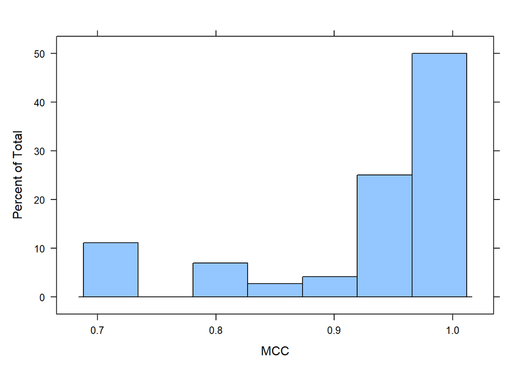

```r
histogram(~mcc, data = model_data,main = "", xlab = "MCC")
```

- Histogram shows the data distribution is not normal

## 3.2 Plot qqnorm and qqline plots

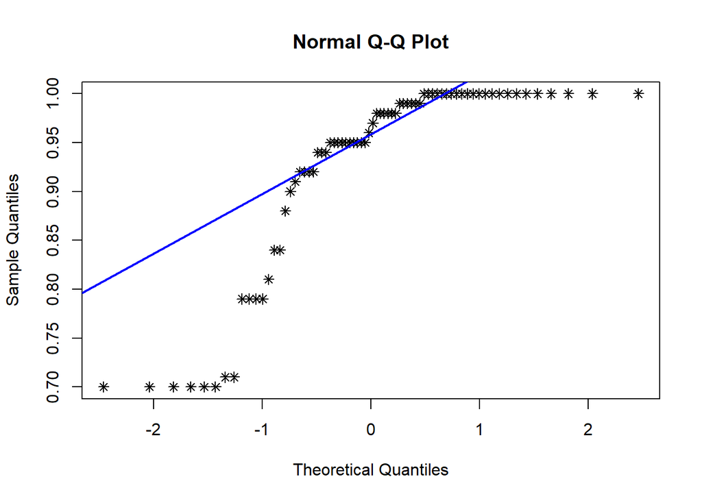

```r
q1<-qqnorm(model_data$mcc, pch =8)
qqline(model_data$mcc, col="blue",lwd = 2)
```

- The data points fall out of the qqline plot

## 3.3 Confirm normality with Shapiro-Wilk Test

```r
shapiro.test(model_data$mcc)
```

```
    Shapiro-Wilk normality test

data:  model_data$mcc
W = 0.73327, p-value = 3.998e-10
```

- The p value from the Shapiro_Wilk normality test is 3.998e-10. The data does not meet the assumption of normality. We, therefore, reject the null hypothesis.

## 3.4 Check for homogeinity of variance with Levene Test

```r
lev_test<-leveneTest(mcc~model, data = model_data) # for the model type
lev_test_2<-leveneTest(mcc~pre_processing, data = model_data) # for pre-processing method
leve_test_3<-leveneTest(mcc~model_preprocessing, data = model_data)
print(lev_test)
```

```
Levene's Test for Homogeneity of Variance (center = median)
      Df F value    Pr(>F)
group  5   4.857 0.0007646 ***
      66
---
Signif. codes:  0 '***' 0.001 '**' 0.01 '*' 0.05 '.' 0.1 ' ' 1
```

```r
print(lev_test_2)
```

```
Levene's Test for Homogeneity of Variance (center = median)
      Df F value Pr(>F)
group 10  1.5115 0.1572
      61
```

```r
print(leve_test_3)
```

```
Levene's Test for Homogeneity of Variance (center = median)
      Df    F value    Pr(>F)
group 65 2.8492e+29 < 2.2e-16 ***
       6
---
Signif. codes:  0 '***' 0.001 '**' 0.01 '*' 0.05 '.' 0.1 ' ' 1
```

** Based on the MCC values and the Levene Test, the assumption of equal variance is violated

## 3.5 Perform Kruskall-Wallis Test due to violation of normality

```r
kruskalTest(mcc~model, data = model_data)
```

```
    Kruskal-Wallis test

data:  mcc by model
chi-squared = 27.159, df = 5, p-value = 5.312e-05
```

```r
kruskalTest(mcc~pre_processing, data = model_data)
```

```
    Kruskal-Wallis test

data:  mcc by pre_processing
chi-squared = 11.894, df = 10, p-value = 0.2922
```

```r
kruskalTest(mcc~model_preprocessing, data = model_data)
```

```
    Kruskal-Wallis test

data:  mcc by model_preprocessing
chi-squared = 62.601, df = 65, p-value = 0.5613
```

### 3.5.1 Perform non-parametric two way ANOVA-Aligned Rank Transform (ART) Analysis of Variance (ART ANOVA)

- This is to check the interaction between model type and spectral pre-processing on their effect on MCC

```r
library(ARTool)
```

#### 3.5.1.1 Aligned Rank Transform (ART) ANOVA

```r
# Apply the aligned rank transform for interactions
model_interac<- art(mcc ~ model * pre_processing, data = model_data)
summary(model_interac)
```

```
Aligned Rank Transform of Factorial Model

Call:
art(formula = mcc ~ model * pre_processing, data = model_data)

Column sums of aligned responses (should all be ~0):
               model       pre_processing model:pre_processing
                   0                    0                    0

F values of ANOVAs on aligned responses not of interest (should all be ~0):
    Min.  1st Qu.   Median     Mean  3rd Qu.     Max.
0.000000 0.000000 0.000000 0.001091 0.000000 0.006548
```

```r
# ANOVA on the transformed data
anova_results <- anova(model_interac)
# Display the ANOVA results for interactions
print(anova_results)
```

```
Analysis of Variance of Aligned Rank Transformed Data

Table Type: Anova Table (Type III tests)
Model: No Repeated Measures (lm)
Response: art(mcc)

                       Df Df.res F value   Pr(>F)
1 model                 5      6 6.48729 0.020719 *
2 pre_processing       10      6 1.89225 0.224624
3 model:pre_processing 50      6 0.47313 0.931974
---
Signif. codes:   0 '***' 0.001 '**' 0.01 '*' 0.05 '.' 0.1 ' ' 1
```

#### 3.5.1.2 Checking for differences within the models

```r
library(dunn.test)
dunn_res <- dunn.test(model_data$mcc, model_data$model, method="bonferroni")
```

```
  Kruskal-Wallis rank sum test

data: x and group
Kruskal-Wallis chi-squared = 27.1589, df = 5, p-value = 0

                           Comparison of x by group
                                 (Bonferroni)
Col Mean-|
Row Mean |        ANN        KNN         NB     PLS-DA         RF
---------+-------------------------------------------------------
     KNN |   1.993088
         |     0.3469
      NB |   4.229721   2.236632
         |    0.0002*     0.1898
  PLS-DA |  -0.407564  -2.400652  -4.637285
         |     1.0000     0.1227    0.0000*
      RF |   1.476177  -0.516910  -2.753543   1.883741
         |     1.0000     1.0000     0.0442     0.4470
     SVM |   1.386712  -0.606375  -2.843008   1.794276  -0.089465
         |     1.0000     1.0000     0.0335     0.5458     1.0000

alpha = 0.05
Reject Ho if p <= alpha/2
```

```r
dunn_res$comparisons
```

```
 [1] "ANN - KNN"    "ANN - NB"     "KNN - NB"     "ANN - PLS-DA" "KNN - PLS-DA"
 [6] "NB - PLS-DA"  "ANN - RF"     "KNN - RF"     "NB - RF"      "PLS-DA - RF"
[11] "ANN - SVM"    "KNN - SVM"    "NB - SVM"     "PLS-DA - SVM" "RF - SVM"
```

#### 3.5.1.3 Check model performance (model and pre_processing)

```r
model_comb<-kruskalTest(model_data$mcc, model_data$model_preprocessing,
                        method = "bonferroni")
print(model_comb)
```

```
    Kruskal-Wallis test

data:  model_data$mcc and model_data$model_preprocessing
chi-squared = 62.601, df = 65, p-value = 0.5613
```

- Specific model in combination with a specific prepossessing techniques do not influence model performance (p = 0.5613)

### 3.5.2 Box plots for visualization

#### 3.5.2.1 Box plot for the model types

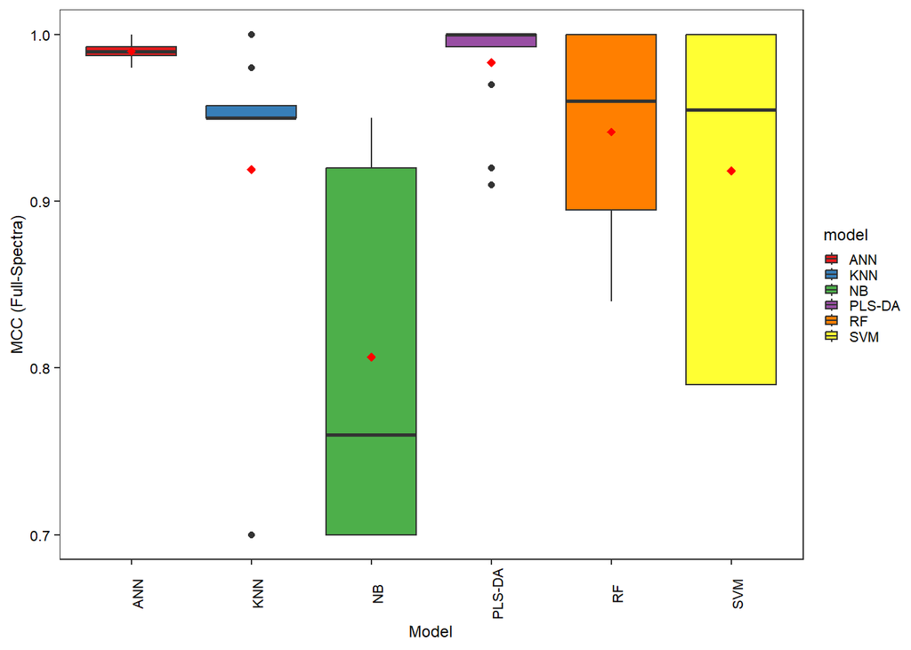

```r
library(patchwork)
p1<-ggplot(data = model_data,mapping = aes(x=model, y = mcc))+
  geom_boxplot(aes(fill= model))+labs(x = "Model", y = "MCC (Full-Spectra)")+theme_bw()+
  theme(axis.title.x = element_text(color = "black",size= 9),
        axis.text.x = element_text(color = "black", angle = 90, size= 8),
        axis.text.y = element_text(color = "black",size =8),
        axis.title.y = element_text(color = "black",size =9),
        panel.grid.major = element_blank(),panel.grid.minor = element_blank(),
        legend.position = "right",
        legend.key.size = unit(0.3, "cm"),
        legend.title = element_text(color = "black",size = 9),
        legend.text = element_text(size = 8),
        legend.spacing.y = unit(0.03, "cm"),
        legend.margin = margin(0.5, 0.5, 0.5, 0.5, "pt"))+
  scale_fill_brewer(palette = "Set1")+ stat_summary(fun=mean, geom="point", shape=18, size=2, color="red")

p1
```

#### 3.5.2.2 Box plot for the pre-processing techniques

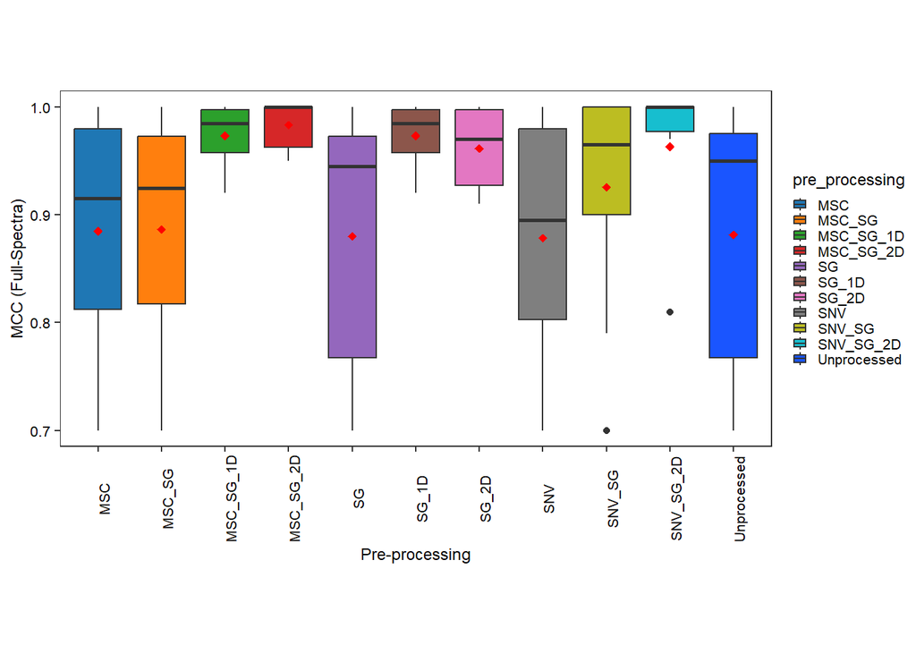

```r
 my_colors <- c("#1f77b4", "#ff7f0e", "#2ca02c", "#d62728", "#9467bd", "#8c564b",
               "#e377c2", "#7f7f7f", "#bcbd22", "#17becf", "#1a55FF", "#9c8305")

 p2<-ggplot(data = model_data,mapping = aes(x=pre_processing, y = mcc))+
  geom_boxplot(aes(fill = pre_processing))+labs(x = "Pre-processing", y = "MCC (Full-Spectra)")+
  theme_bw()+
  theme(axis.title.x = element_text(color = "black", size =9),
        axis.title.y = element_text(colour = "black", size =9),
        axis.text.y = element_text(color = "black",size =8),
        axis.text.x = element_text(color = "black",size = 8,angle = 90),
        panel.grid.major = element_blank(),panel.grid.minor = element_blank(),
        legend.position = "right")+scale_color_manual(values = my_colors)+
   scale_fill_manual(values = my_colors)+ theme(
  legend.key.size = unit(0.3, "cm"),  legend.text = element_text(size = 8),
  legend.spacing.y = unit(0.03, "cm"),
  legend.margin = margin(0.5, 0.5, 0.5, 0.5, "pt"))+
   theme(legend.title = element_text(color = "black",size = 9),
         aspect.ratio = 0.5)+
   stat_summary(fun=mean, geom="point", shape=18, size=2, color="red")
 p2
```

## 3.6 Models based on variable reduction

```r
#Load data
model_data_2<-read_excel("Compiled_Model_1SE.xlsx",sheet = "Sheet2")
model_data_2<-clean_names(model_data_2)
colnames(model_data_2)
```

```
[1] "pre_processing"      "model"               "model_preprocessing"
[4] "mcc"
```

```r
#Convert the pre-processing and models to factors
model_data_2$pre_processing<-as.factor(model_data_2$pre_processing)
model_data_2$model<-as.factor(model_data_2$model)
model_data_2$model_preprocessing<-as.factor(model_data_2$model_preprocessing)
```

## 3.7 Check normality and equality of variance

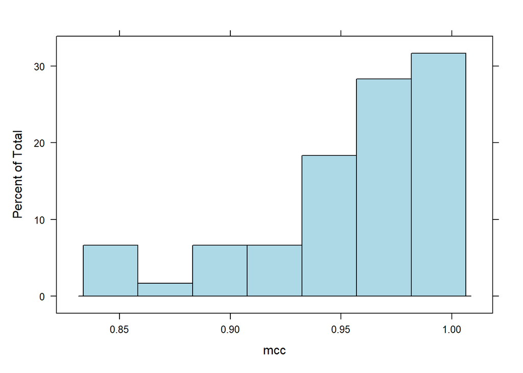

```r
histogram(~mcc, data = model_data_2, col = "lightblue")
```

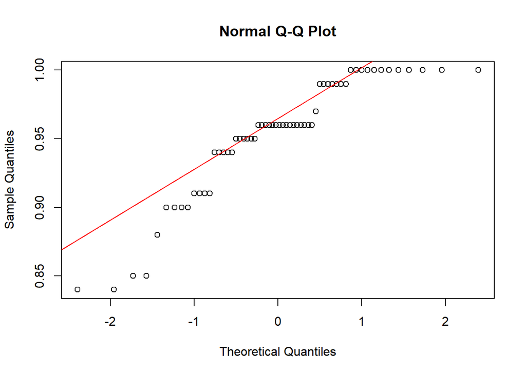

```r
qqnorm(model_data_2$mcc)
qqline(model_data_2$mcc, col = "red")
```

- The plots reveal the data is not normal

## 3.8 Confirm with the statistical tests

```r
#Normality
shapiro.test(model_data_2$mcc)
```

```
    Shapiro-Wilk normality test

data:  model_data_2$mcc
W = 0.87179, p-value = 1.427e-05
```

```r
#Homogeneity of variance

leveneTest(mcc~model, data = model_data_2)
```

```
Levene's Test for Homogeneity of Variance (center = median)
      Df F value Pr(>F)
group  4  1.0166 0.4069
      55
```

```r
leveneTest(mcc~pre_processing, data = model_data_2)
```

```
Levene's Test for Homogeneity of Variance (center = median)
      Df F value  Pr(>F)
group 10   1.768 0.09207 .
      49
---
Signif. codes:  0 '***' 0.001 '**' 0.01 '*' 0.05 '.' 0.1 ' ' 1
```

```r
leveneTest(mcc~model_preprocessing, data = model_data_2)
```

```
Levene's Test for Homogeneity of Variance (center = median)
      Df    F value    Pr(>F)
group 54 5.0119e+28 < 2.2e-16 ***
       5
---
Signif. codes:  0 '***' 0.001 '**' 0.01 '*' 0.05 '.' 0.1 ' ' 1
```

- The assumption of normality is violated. Reject the null hypothesis. Therefore, opt for non-parametric tests ANOVA

#### 3.8.0.1 Perform Aligned Rank Transform (ART) to check for interactions

```r
# Apply the aligned rank transform for interactions
model_interac_2<- art(mcc ~ model * pre_processing, data = model_data_2)
summary(model_interac_2)
```

```
Aligned Rank Transform of Factorial Model

Call:
art(formula = mcc ~ model * pre_processing, data = model_data_2)

Column sums of aligned responses (should all be ~0):
               model       pre_processing model:pre_processing
                   0                    0                    0

F values of ANOVAs on aligned responses not of interest (should all be ~0):
   Min. 1st Qu.  Median    Mean 3rd Qu.    Max.
0.00000 0.00000 0.00000 0.02381 0.00000 0.14289
```

```r
# ANOVA on the transformed data
anova_results_2 <- anova(model_interac_2)
# Display the ANOVA results for interactions
print(anova_results_2)
```

```
Analysis of Variance of Aligned Rank Transformed Data

Table Type: Anova Table (Type III tests)
Model: No Repeated Measures (lm)
Response: art(mcc)

                       Df Df.res F value   Pr(>F)
1 model                 4      5  8.5313 0.018568 *
2 pre_processing       10      5  1.1668 0.458921
3 model:pre_processing 40      5  1.3491 0.402827
---
Signif. codes:   0 '***' 0.001 '**' 0.01 '*' 0.05 '.' 0.1 ' ' 1
```

- The models influence the MCC results after variable reduction

#### 3.8.0.2 Perform Dunn Test to check where the differences lie within the models

```r
dunn_res_2 <- dunn.test(model_data_2$mcc, model_data_2$model, method="bonferroni")
```

```
  Kruskal-Wallis rank sum test

data: x and group
Kruskal-Wallis chi-squared = 27.6808, df = 4, p-value = 0

                           Comparison of x by group
                                 (Bonferroni)
Col Mean-|
Row Mean |        ANN        KNN     PLS-DA         RF
---------+--------------------------------------------
     KNN |   3.917352
         |    0.0004*
  PLS-DA |   0.201802  -3.715549
         |     1.0000    0.0010*
      RF |   3.181364  -0.735987   2.979561
         |    0.0073*     1.0000    0.0144*
     SVM |   3.264460  -0.652892   3.062657   0.083095
         |    0.0055*     1.0000    0.0110*     1.0000

alpha = 0.05
Reject Ho if p <= alpha/2
```

```r
dunn_res_2$comparisons
```

```
 [1] "ANN - KNN"    "ANN - PLS-DA" "KNN - PLS-DA" "ANN - RF"     "KNN - RF"
 [6] "PLS-DA - RF"  "ANN - SVM"    "KNN - SVM"    "PLS-DA - SVM" "RF - SVM"
```

- Both PLS-DA and ANN models outperform KNN, RF, and SVM models.

## 3.9 Plotting

### 3.9.1 Models from variable selection

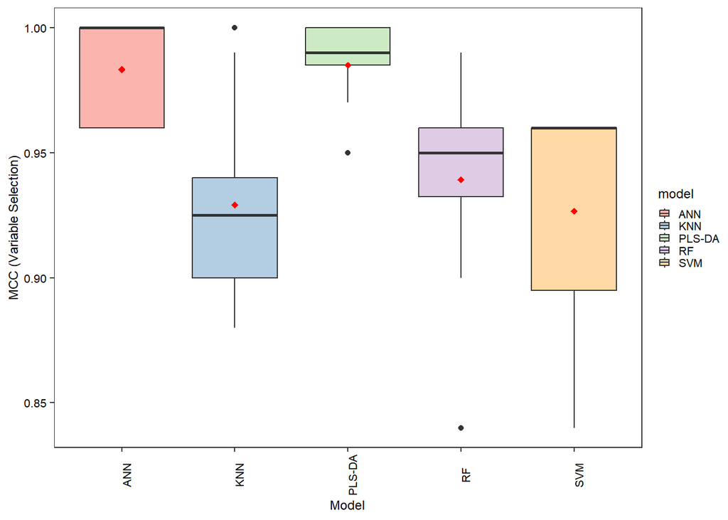

```r
p3<-ggplot(data = model_data_2,mapping = aes(x=model, y = mcc))+
  geom_boxplot(aes(fill= model))+labs(x = "Model", y = "MCC (Variable Selection)")+
  theme_bw()+
  theme(axis.title.x = element_text(color = "black",size = 9),
        axis.text.x = element_text(color = "black", angle = 90, size = 8),
        axis.text.y = element_text(color = "black",size = 8),
        axis.title.y = element_text(color = "black", size = 9),
        panel.grid.major = element_blank(),
        panel.grid.minor = element_blank(),
        legend.position = "right",legend.key.size = unit(0.3, "cm"),
        legend.title = element_text(color = "black",size = 9),
        legend.text = element_text(size = 8),
        legend.spacing.y = unit(0.03, "cm"),
        legend.margin = margin(0.5, 0.5, 0.5, 0.5, "pt"))+
  scale_fill_brewer(palette = "Pastel1")+
  stat_summary(fun = mean,geom = "point",shape = 18, size = 2, color = "red")

p3
```

### 3.9.2 Spectral Pre-processing vs MCC after variable reduction

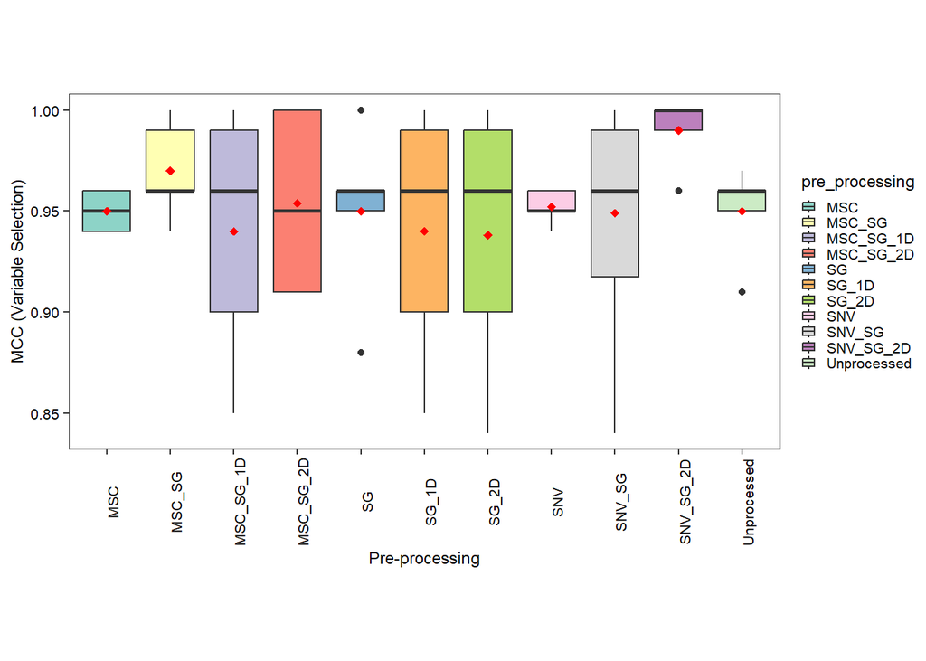

```r
p4<-ggplot(data = model_data_2,mapping = aes(x=pre_processing, y = mcc))+
  geom_boxplot(aes(fill = pre_processing))+labs(x = "Pre-processing", y = "MCC (Variable Selection)")+
  theme_bw()+
  theme(axis.title.x = element_text(color = "black", size = 9),
        axis.title.y = element_text(color = "black", size = 9),
        axis.text.x = element_text(color = "black",angle = 90, size = 8),
        axis.text.y = element_text(color = "black",size = 8),
        panel.grid.major = element_blank(),panel.grid.minor = element_blank(),
        legend.position = "right")+
  theme(legend.key.size = unit(0.3, "cm"),
        legend.title = element_text(color = "black",size = 9),
        legend.text = element_text(size = 8),
        legend.spacing.y = unit(0.03, "cm"),
        legend.margin = margin(0.5, 0.5, 0.5, 0.5, "pt"),aspect.ratio = 0.5)+
  stat_summary(fun=mean, geom="point", shape=18, size=2, color="red")+
  scale_fill_brewer(palette = "Set3")
p4
```

## 3.10 Check the performance of each model with and without variable selection using Wilcoxon Signed Rank test since the samples are paired

```r
# Overall model performance
#Load data
model_data_3<-read_excel("Compiled_Model_1SE.xlsx",sheet = "Sheet3")
model_data_3<-clean_names(model_data_3)
colnames(model_data_3)
```

```
[1] "pre_processing"      "model"               "model_preprocessing"
[4] "mcc_1"               "mcc_2"
```

```r
#Convert the pre-processing and models to factors
model_data_3$pre_processing<-as.factor(model_data_3$pre_processing)
model_data_3$model<-as.factor(model_data_3$model)
model_data_3$model_preprocessing<-as.factor(model_data_3$model_preprocessing)
```

- All the test comparison will be based on the ‘model type’ considering that it is the main significant factor influencing Matthews Correlation Coefficient (MCC).
- Additionally, normality assumption is violated, we will therefore proceed with non-parametric t-tests

## 3.11 Overall models with and without variable selection

```r
overall_wilcox_test<-wilcox.test(model_data_3$mcc_1,model_data_3$mcc_2,
                                 paired = TRUE, alternative = "two.sided")
print(overall_wilcox_test)
```

```
    Wilcoxon signed rank test with continuity correction

data:  model_data_3$mcc_1 and model_data_3$mcc_2
V = 748.5, p-value = 0.4237
alternative hypothesis: true location shift is not equal to 0
```

```r
wilcox.test(model_data_3$mcc_1,model_data_3$mcc_2,
                                 paired = TRUE, alternative = "greater")
```

```
    Wilcoxon signed rank test with continuity correction

data:  model_data_3$mcc_1 and model_data_3$mcc_2
V = 748.5, p-value = 0.2119
alternative hypothesis: true location shift is greater than 0
```

```r
wilcox.test(model_data_3$mcc_1,model_data_3$mcc_2,
                                 paired = TRUE, alternative = "less")
```

```
    Wilcoxon signed rank test with continuity correction

data:  model_data_3$mcc_1 and model_data_3$mcc_2
V = 748.5, p-value = 0.7909
alternative hypothesis: true location shift is less than 0
```

- The p value = 0.4237. Therefore, there is no significant difference in overall model performance before and after variable reduction.

## 3.12 PLS-DA model with and without variable selection

```r
pls_data<-subset(model_data_3,model == "PLS-DA",
                 select = c("model","mcc_1","mcc_2"))
head(pls_data)
```

```
# A tibble: 6 × 3
  model  mcc_1 mcc_2
  <fct>  <dbl> <dbl>
1 PLS-DA  1     0.97
2 PLS-DA  1     1
3 PLS-DA  1     0.99
4 PLS-DA  0.91  0.99
5 PLS-DA  1     0.95
6 PLS-DA  1     0.99
```

```r
dim(pls_data)
```

```
[1] 12  3
```

```r
plsda_wilcox_test<-wilcox.test(pls_data$mcc_1,pls_data$mcc_2,
                                paired = TRUE, alternative = "two.sided")
print(plsda_wilcox_test)
```

```
    Wilcoxon signed rank test with continuity correction

data:  pls_data$mcc_1 and pls_data$mcc_2
V = 30.5, p-value = 0.7972
alternative hypothesis: true location shift is not equal to 0
```

```r
mean(pls_data$mcc_1)
```

```
[1] 0.9833333
```

```r
mean(pls_data$mcc_2)
```

```
[1] 0.985
```

## 3.13 K-Nearest Neighbor Model with and without Variable Selection

```r
knn_data<-subset(model_data_3,model == "KNN",
                 select = c("model","mcc_1","mcc_2"))
head(knn_data)
```

```
# A tibble: 6 × 3
  model mcc_1 mcc_2
  <fct> <dbl> <dbl>
1 KNN    0.7   0.91
2 KNN    0.7   0.88
3 KNN    0.95  0.9
4 KNN    0.95  0.9
5 KNN    0.95  0.94
6 KNN    0.95  0.94
```

```r
dim(knn_data)
```

```
[1] 12  3
```

```r
knn_wilcox_test<-wilcox.test(knn_data$mcc_1,knn_data$mcc_2,
                                paired = TRUE, alternative = "two.sided")
print(knn_wilcox_test)
```

```
    Wilcoxon signed rank test with continuity correction

data:  knn_data$mcc_1 and knn_data$mcc_2
V = 42, p-value = 0.4444
alternative hypothesis: true location shift is not equal to 0
```

```r
mean(knn_data$mcc_1)
```

```
[1] 0.9191667
```

```r
mean(knn_data$mcc_2)
```

```
[1] 0.9291667
```

- There is no significant difference in performance in the KNN models with and without variable selection

## 3.14 Random Forest Model with and without Variable Selection

```r
RF_data<-subset(model_data_3,model == "RF",
                 select = c("model","mcc_1","mcc_2"))
head(RF_data)
```

```
# A tibble: 6 × 3
  model mcc_1 mcc_2
  <fct> <dbl> <dbl>
1 RF     0.94  0.95
2 RF     0.94  0.95
3 RF     0.98  0.96
4 RF     1     0.96
5 RF     0.84  0.95
6 RF     0.84  0.84
```

```r
dim(RF_data)
```

```
[1] 12  3
```

```r
RF_wilcox_test<-wilcox.test(RF_data$mcc_1,RF_data$mcc_2,
                                paired = TRUE, alternative = "two.sided")
print(RF_wilcox_test)
```

```
    Wilcoxon signed rank test with continuity correction

data:  RF_data$mcc_1 and RF_data$mcc_2
V = 36, p-value = 0.8236
alternative hypothesis: true location shift is not equal to 0
```

```r
mean(RF_data$mcc_1)
```

```
[1] 0.9416667
```

```r
mean(RF_data$mcc_2)
```

```
[1] 0.9391667
```

- There is no significant difference in performance in the RF models with and without variable selection

## 3.15 SVM Model with and without Variable Selection

```r
SVM_data<-subset(model_data_3,model == "SVM",
                 select = c("model","mcc_1","mcc_2"))
head(SVM_data)
```

```
# A tibble: 6 × 3
  model mcc_1 mcc_2
  <fct> <dbl> <dbl>
1 SVM    0.96  0.96
2 SVM    0.95  0.96
3 SVM    1     0.85
4 SVM    1     0.84
5 SVM    0.79  0.96
6 SVM    0.79  0.96
```

```r
dim(SVM_data)
```

```
[1] 12  3
```

```r
SVM_wilcox_test<-wilcox.test(SVM_data$mcc_1,SVM_data$mcc_2,
                                paired = TRUE, alternative = "two.sided")
print(SVM_wilcox_test)
```

```
    Wilcoxon signed rank test with continuity correction

data:  SVM_data$mcc_1 and SVM_data$mcc_2
V = 20, p-value = 0.4724
alternative hypothesis: true location shift is not equal to 0
```

```r
mean(SVM_data$mcc_1)
```

```
[1] 0.9183333
```

```r
mean(SVM_data$mcc_2)
```

```
[1] 0.9266667
```

- There is no significant difference in performance in the SVM models with and without variable selection

## 3.16 Artificial Neural Network Model with and without Variable Selection

```r
ANN_data<-subset(model_data_3,model == "ANN",
                 select = c("model","mcc_1","mcc_2"))
head(ANN_data)
```

```
# A tibble: 6 × 3
  model mcc_1 mcc_2
  <fct> <dbl> <dbl>
1 ANN    0.98  0.96
2 ANN    0.98  0.96
3 ANN    0.99  1
4 ANN    0.99  1
5 ANN    0.99  0.96
6 ANN    0.99  0.96
```

```r
dim(ANN_data)
```

```
[1] 12  3
```

```r
ANN_wilcox_test<-wilcox.test(ANN_data$mcc_1,ANN_data$mcc_2,
                                paired = TRUE, alternative = "two.sided")
print(ANN_wilcox_test)
```

```
    Wilcoxon signed rank test with continuity correction

data:  ANN_data$mcc_1 and ANN_data$mcc_2
V = 34, p-value = 0.1878
alternative hypothesis: true location shift is not equal to 0
```

```r
mean(ANN_data$mcc_1)
```

```
[1] 0.99
```

```r
mean(ANN_data$mcc_2)
```

```
[1] 0.9833333
```

- NNET model performance does not differ either with or without variable selection

## 3.17 Reference

- Wobbrock, J. O., Findlater, L., Gergle, D., and Higgins, J. J. (2011). The aligned rank transform for nonparametric factorial analyses using only ANOVA procedures. Proceedings of the ACM Conference on Human Factors in Computing Systems (CHI ’11). Vancouver, British Columbia (May 7–12, 2011). New York: ACM Press, pp. 143–146. doi: 10.1145/1978942.1978963